# Variety-Trial Model Validation

AJ

# 1 Purpose

This document validates that the new spatial + multi-environment (MET) workflow estimates what we intend and quantifies how well it performs, using the simulated variety-trial data.

**We check:**

1. Recovery of entry effects and ranks versus known simulation truth.
2. Stage‑1 spatial model selection behavior.
3. Uncertainty calibration and practical interpretability (CIs, Tukey letters).
4. Optional diagnostics on variance components and residual structure.

# 2 Data inputs and file structure

This validation assumes the Rmd file lives in the project’s `code/` folder and the backend has been run with `DATA_MODE = "sim"` so that all simulated outputs are available.

Expected files (relative to the project root):

- `sim_data/trial_sim.csv`: simulated plots with columns `site, year, env, rep, row, col, entry, yield`.
- `sim_data/entry_truth.csv`: known entry main effects used to simulate data.
- `sim_output/lsm_stage1.csv`: per‑environment LS‑means and SEs after spatial + fallback modeling.
- `sim_output/lsm_across.csv`: across‑environment LS‑means (MET stage‑2).
- `sim_output/diffs_across.csv`: Tukey‑adjusted pairwise comparisons across environments.
- `sim_output/cld_across.csv`: compact letter display (“grouping letters”) across environments.
- `sim_output/entry_blups.csv`: BLUPs of entry effects from the MET model.
- `sim_output/run_report.txt`: textual summary of modeling choices and assumptions.

# 3 1. Recovery of entry effects and ranks

**Goal.** Across environments, entries’ adjusted means and BLUPs should track the true entry effects used in simulation.

**Metrics reported.** Spearman rank correlation (ranking fidelity) and RMSE (numerical accuracy).

```
## # A tibble: 2 × 3
##   source              rank_cor   rmse
##   <chr>                  <dbl>  <dbl>
## 1 Across-env LS-means    0.917 4449.
## 2 BLUPs                  0.862   87.2
```

Higher rank correlation indicates better retention of ordering among entries, while lower RMSE indicates closer numerical recovery. In many MET settings, BLUPs stabilize ranks under unbalanced or noisy data, so it is informative to compare both summaries.

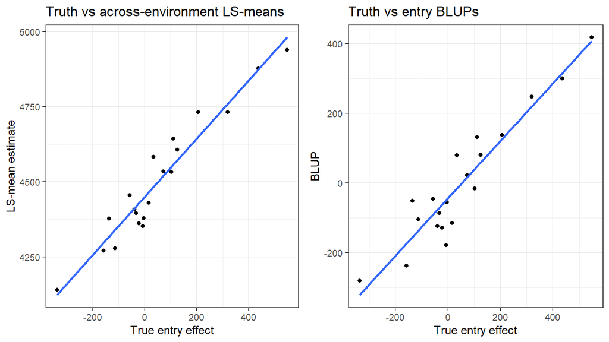

# 4 2. Stage‑1 spatial model selection

**Goal.** Confirm that, per environment, AICc selects plausible covariance families and that fallbacks are triggered only when needed.

```
## $`Chosen covariance per environment`
## # A tibble: 6 × 3
##   env              cov       n
##   <chr>            <chr> <int>
## 1 Akron_2024       sph      16
## 2 Akron_2025       gau      16
## 3 FortCollins_2024 sph      16
## 4 FortCollins_2025 expa     16
## 5 RockyFord_2024   sph      16
## 6 RockyFord_2025   gau      16
##
## $`Overall covariance frequency`
## # A tibble: 3 × 3
##   cov       n  prop
##   <chr> <int> <dbl>
## 1 expa     16 0.167
## 2 gau      32 0.333
## 3 sph      48 0.5
```